# Automated Diagnosis of Atrial Fibrillation

## Philip Mathew

```python
import numpy as np
import multiprocessing
import matplotlib.pyplot as plt
from tqdm import tqdm, trange
from pathlib import Path
import pandas as pd
import scipy.io

def load_raw_waveform(mat_file):
    return scipy.io.loadmat(str(mat_file))['val'][0] # in case it's given a Path object or something

TRAINVAL_FOLDER =  Path.cwd() / 'physionet-afib-data' / 'training'
TEST_FOLDER =  Path.cwd() / 'physionet-afib-data' / 'validation'

SAMPLE_RATE = 300

reference_trainval_df = pd.read_csv(str(TRAINVAL_FOLDER / 'REFERENCE.csv'), names=['wave', 'label'])
reference_test_df = pd.read_csv(str(TEST_FOLDER / 'REFERENCE.csv'), names=['wave', 'label'])
```

# Motivation

[Atrial fibrillation](https://www.hopkinsmedicine.org/health/conditions-and-diseases/atrial-fibrillation-prevention-treatment-and-research), or AFib for short, is he most common type of arrythmia (abnormal heartbeat) found in people. AFib comes from disorganized electrical signals in the heart, causing the upper two chambers to quiver when the heart is pumping blood. While normal heartbeats are periodic in nature, this quiver in your heart causes an irregular, non-periodic heartbeat. While some can live more-or-less unaffected by AFib, it significantly increases one's risk of stroke. In extreme cases, AFib can result in heart failure. It has also been linked to dementia.

As such, being able to diagnose AFib is extremely important. The best way to detect AFib involves examining a patient's ECG wave. ECG waves measure the electrical activity of the heart over time, generating the fmailiar PQRST wave below.

[figure not shown]

We can examine these ECG waves using modern deep-learning methods, specifically using a 1-dimensional convolutional neural network for classification purposes. We'll discuss that later though, let's first gather some data!

# Data Gathering

The data we're using comes from the [2017 PhysioNet Challenge](https://physionet.org/content/challenge-2017/1.0.0/), and is already partioned into a training and validation set. However, since the test set used by the competition is not given with labels, we will be using the validation set as our "test" set, and partitioning the given training set into training and validation sets for this tutorial.

Furthermore, the data is partitioned into 4 distinct clases:

- Normal
- Atrial Fibrillation (AFib)
- Other
- Noisy

Now, for the purposes of a tutorial like this, having some state-of-the-art model that can distinguish between AF and other confusers (i.e. some sort of non-AFib arrythmia) is not exactly the intent (nor is it entirely feasible given that I can only do so much with a single RTX 2080 Super at my disposal). Moreover, having to distinguish between noisy signals and real signals is again a little beyond the scope of this project. As a result, we will be omitting any examples from those classes. On the plus side, this creates a nice binary classification problem.

```python
trainval_df = reference_trainval_df[reference_trainval_df['label'].isin(('N', 'A'))]
test_df = reference_test_df[reference_test_df['label'].isin(('N', 'A'))]
```

Before we proceed with any of the fun parts, let's examine the attributes of our data. PhysioNet says that the given ECG waves were collected with a sample rate of 300 Hz, wich durations anywhere from 9 seconds to 60 seconds. Unfortunately, having waves of differing dimensions is not exactly ideal for any machine-learning techniques, so we need to examine the distribution of signal durations and see what we're working with here.

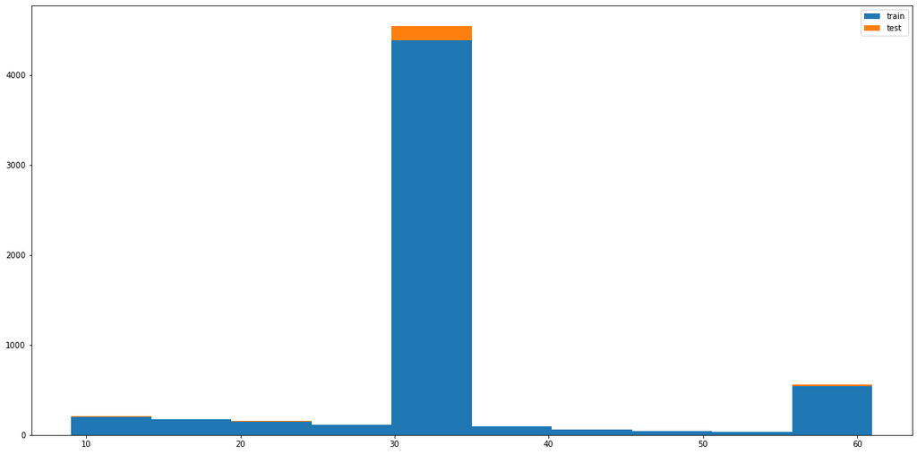

```python
train_durations = []
for i in trange(len(trainval_df)):
    mat_file = TRAINVAL_FOLDER / f"{trainval_df.iloc[i]['wave']}.mat"
    wave = load_raw_waveform(mat_file)
    train_durations.append(len(wave) / SAMPLE_RATE)

test_durations = []
for i in trange(len(test_df)):
    mat_file = TEST_FOLDER / f"{test_df.iloc[i]['wave']}.mat"
    wave = load_raw_waveform(mat_file)
    test_durations.append(len(wave) / SAMPLE_RATE)

fig, ax = plt.subplots(1, 1, figsize=(20, 10))
ax.hist([train_durations, test_durations], stacked=True, label=['train', 'test'])
ax.legend();
```

Well, thats quite fortunate isn't it? Most of our data was collected for 30-35 seconds, so we can safely discard any ECG wave with a duration less than 30 seconds. For anything more, we can just cut it off after 30 seconds.

Now, let's see how the durations are distributed over the two classes.

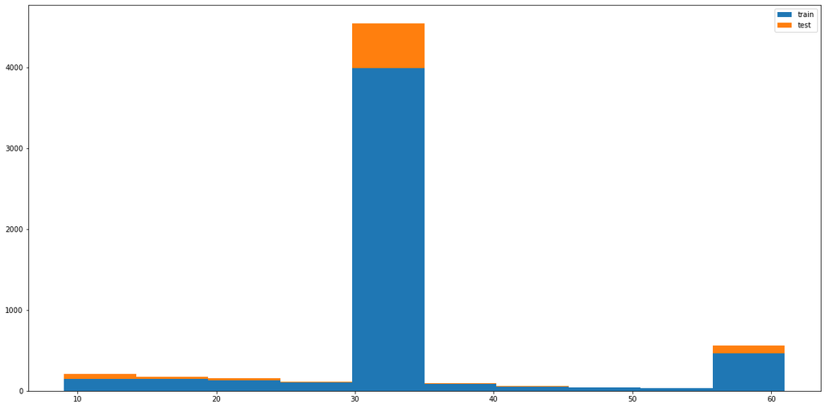

```python
normal_durations, af_durations = [], []
for i in trange(len(trainval_df)):
    mat_file = TRAINVAL_FOLDER / f"{trainval_df.iloc[i]['wave']}.mat"
    wave = load_raw_waveform(mat_file)
    if trainval_df.iloc[i]['label'] == 'N':
        normal_durations.append(len(wave) / SAMPLE_RATE)
    else:
        af_durations.append(len(wave) / SAMPLE_RATE)
for i in trange(len(test_df)):
    mat_file = TEST_FOLDER / f"{test_df.iloc[i]['wave']}.mat"
    wave = load_raw_waveform(mat_file)
    if test_df.iloc[i]['label'] == 'N':
        normal_durations.append(len(wave) / SAMPLE_RATE)
    else:
        af_durations.append(len(wave) / SAMPLE_RATE)

fig, ax = plt.subplots(1, 1, figsize=(20, 10))
ax.hist([normal_durations, af_durations], stacked=True, label=['train', 'test'])
ax.legend();
```

Lovely! Since most of the data is, again, 30 seconds or longer in duration, we can safely limit ourselves to these entries without risking losing too much data.

```python
def remove_short_ECGs(df, mat_file_dir):
    inds_to_keep = []
    for i in trange(len(df)):
        mat_file = mat_file_dir / f"{df.iloc[i]['wave']}.mat"
        wave = load_raw_waveform(mat_file)
        if (len(wave) / SAMPLE_RATE) >= 30:
            inds_to_keep.append(i)

    ret_df = df.iloc[inds_to_keep]

    return ret_df.reset_index().drop('index', axis=1)

trainval_df = remove_short_ECGs(trainval_df, TRAINVAL_FOLDER)
test_df = remove_short_ECGs(test_df, TEST_FOLDER)
```

Awesome, now that we've cut out any ECG waves that are too small, let's move on to preprocessing.

# Data Preprocessing

Let's plot one waveform from each class.

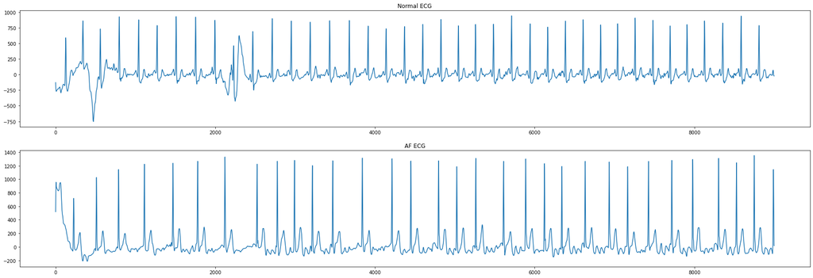

```python
def load_waveform(mat_file):
    s = load_raw_waveform(mat_file)
    return s[0:(30 * SAMPLE_RATE)]

normal_wave_file = TRAINVAL_FOLDER / f"{trainval_df[trainval_df['label'] == 'N'].iloc[0]['wave']}.mat"
af_wave_file = TRAINVAL_FOLDER / f"{trainval_df[trainval_df['label'] == 'A'].iloc[0]['wave']}.mat"

normal_wave, af_wave = load_waveform(normal_wave_file), load_waveform(af_wave_file)

fig, (ax1, ax2) = plt.subplots(2, 1, figsize=(30, 10))

ax1.plot(normal_wave)
ax1.set_title("Normal ECG")

ax2.plot(af_wave)
ax2.set_title("AF ECG");
```

Now, from examination we can see that the waves are certainly different, with the normal wave being much more periodic than the AFib wave. This can be easily seen through the somewhat-constant peak-to-peak distances for the normal wave, while the AF wave has highly irregular peak-to-peak distances. However, the waves are both in a less-than-ideal state, since they're clearly quite noisy, and the baseline clearly fluctuates from 0. As a result, we need to do some filtering in order to make these waves useable.

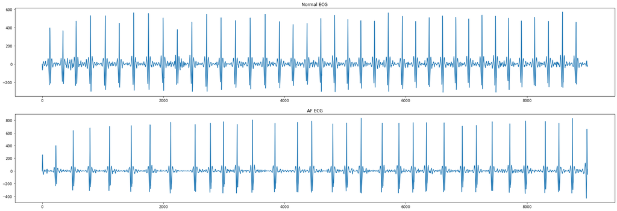

```python
from scipy.signal import butter, filtfilt

def filter_wave(s):
    a, b = butter(5, .05, 'highpass')
    return filtfilt(a, b, s)

fig, (ax1, ax2) = plt.subplots(2, 1, figsize=(30, 10))

ax1.plot(filter_wave(normal_wave))
ax1.set_title("Normal ECG")

ax2.plot(filter_wave(af_wave))
ax2.set_title("AF ECG");
```

Much better! We can now pretty easily see the characteristically irregular heartbeat associated with AFib, which is demonstrated through the inconsistent peak-to-peak distances in the second wave as compared to the first wave. Now, for ease of use, let's just normalize these waves before moving on.

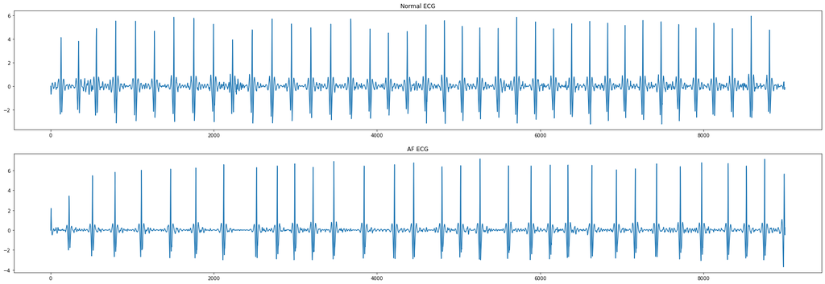

```python
def normalize_wave(s):
    return (s - np.mean(s)) / np.std(s)

def preprocess_wave(s):
    return normalize_wave(filter_wave(s))

fig, (ax1, ax2) = plt.subplots(2, 1, figsize=(30, 10))

ax1.plot(preprocess_wave(normal_wave))
ax1.set_title("Normal ECG")

ax2.plot(preprocess_wave(af_wave))
ax2.set_title("AF ECG");
```

Lovely, let's move on now.

# Dealing with Imbalanced Data

Let's plot the distribution of our data over the two classes.

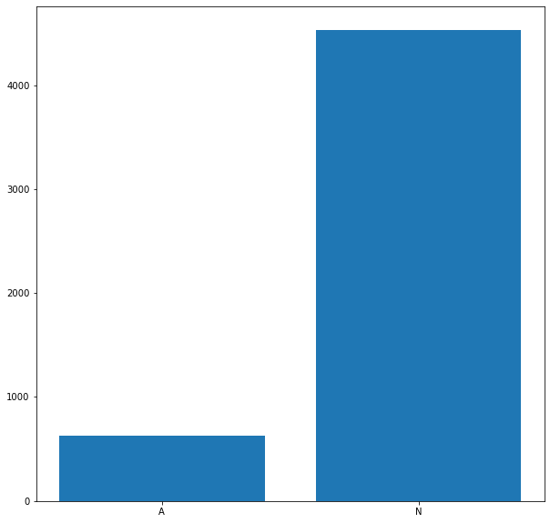

```python
fig, ax = plt.subplots(1, 1, figsize=(10, 10))

labels, heights = np.unique(trainval_df['label'], return_counts=True)

ax.bar(labels, heights);
```

Now, you may be asking "What is oversampling?" Oversampling is a way to combat data imbalance by increasing the amount of examples for classes where one needs more examples. Oversampling techniques can range from naively duplicating data (a.k.a. random oversampling) to attempting to create new data from thin air. Obviously, it's not a direct substitute for simply collecting more data, however for situations where more data can not be collected (such as this one), this becomes a viable solution.

Before we discuss which techniques we will be using, let's first partition our data into a training and validation set. Note that oversampling is only for the training set, and should not be used on the validation set. As a result, we want to make a validation set with equal amounts of data from both classes. We will split the data as follows: 20% of class A will be held out as examples, then we will add to that set an equivalent number of examples from class N as we have from class A.

```python
af_inds = list(trainval_df[trainval_df['label'] == 'A'].index)
np.random.shuffle(af_inds)
af_val_inds = af_inds[0:int(.2 * len(af_inds))]

normal_inds = list(trainval_df[trainval_df['label'] == 'N'].index)
np.random.shuffle(normal_inds)
normal_val_inds = normal_inds[0:len(af_val_inds)]

val_inds = normal_val_inds + af_val_inds
val_df = trainval_df.iloc[val_inds]

train_df = trainval_df.drop(val_df.index)

train_df = train_df.reset_index().drop('index', axis=1)
val_df = val_df.reset_index().drop('index', axis=1)

print(f'{len(train_df)} training examples ({len(train_df[train_df["label"] == "N"])} normal, {len(train_df[train_df["label"] == "A"])} AFib)')
print(f'{len(val_df)} validation examples ({len(val_df[val_df["label"] == "N"])} normal, {len(val_df[val_df["label"] == "A"])} AFib)')
```

```
4904 training examples (4404 normal, 500 AFib)
250 validation examples (125 normal, 125 AFib)
```

Ok, now for choosing an oversampling technique. While random oversampling is possible, the amount of times that we would have to replicate existing data to curb the imabalance would result in some serious overfitting in the model. As a result, we are going to use a technique called SMOTE, which one can read more about [here](https://arxiv.org/abs/1106.1813). In short, SMOTE makes data of of thin air, which will help us in this situation. We will be using the `imblearn` library in order to generate this data.

Now one downside to this is that we'll need to load all of the training data in at once, so let's get on with that now.

```python
train_waves, train_labels = [], []
for i, row in tqdm(train_df.iterrows(), total=len(train_df)):
    train_waves.append(preprocess_wave(load_waveform(TRAINVAL_FOLDER / f"{row['wave']}.mat")))
    train_labels.append(row['label'])

val_waves, val_labels = [], []
for i, row in tqdm(val_df.iterrows(), total=len(val_df)):
    val_waves.append(preprocess_wave(load_waveform(TRAINVAL_FOLDER / f"{row['wave']}.mat")))
    val_labels.append(row['label'])

X_train, X_val, y_train, y_val = np.asarray(train_waves), np.asarray(val_waves), np.asarray(train_labels), np.asarray(val_labels)
```

Time for the oversampling!

```python
from imblearn.over_sampling import SMOTE

sm = SMOTE(sampling_strategy='minority', n_jobs=multiprocessing.cpu_count())
X_train_res, y_train_res = sm.fit_resample(X_train, y_train)
```

Ok cool, let's see what the training set looks like now!

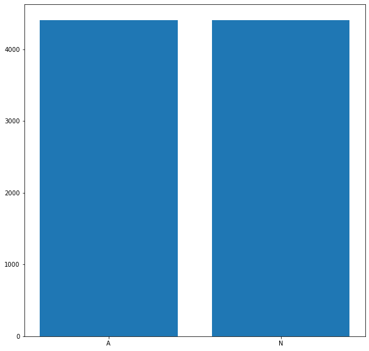

```python
fig, ax = plt.subplots(1, 1, figsize=(10, 10))

labels, heights = np.unique(y_train_res, return_counts=True)

ax.bar(labels, heights);
```

Much better! Now we can finally move on to the piece de resistance: the model.

# Model Training

Now, a task like diagnosing AFib requires a model that's up to the task. We will be utilizing a one-dimensional convolutional neural network (CNN), which I've dubbed "TPMNet" because I think it sounds cute. CNN's have gained major recognition for their effectiveness in the field of computer vision. interestignly enough, the whole concept of convolution filters are also quite effective in the 1-dimensional case, where one can think of the filters as sliding windows over the graph of the function instead of over a matrix.

We will train the network using ADAM optimizer, with categorical cross-entropy loss (the standard loss function for classification tasks).

One may wonder whether TPMNet is sufficient for our task, since it's quite a small network. However, having a small network significantly reduces our computational cost, and as we'll see in it's perfmorance later, size doesn't always matter.

```python
import tensorflow as tf
from tensorflow.keras.layers import *

input_shape = (X_train_res[0].shape[0], 1)

def reshape_for_NN(arr):
  return arr.reshape(arr.shape[0], arr.shape[1], 1) # change shape of array to allow for proper input into NN

model = tf.keras.Sequential()
model.add(InputLayer(input_shape=input_shape))
model.add(Conv1D(256, kernel_size=100, activation='relu'))
model.add(AveragePooling1D(pool_size=2))
model.add(Conv1D(128, kernel_size=5, activation='relu'))
model.add(AveragePooling1D(pool_size=2))
model.add(Conv1D(64, kernel_size=3, activation='relu'))
model.add(GlobalAveragePooling1D())
model.add(Dense(2, activation='softmax')) # output layer

model.compile(optimizer = 'Adam', loss = 'categorical_crossentropy', metrics = ['accuracy']) # compile with the necessary optimizer and loss function
model.summary()
```

```
Model: "sequential"
_________________________________________________________________
 Layer (type)                Output Shape              Param #
=================================================================
 conv1d (Conv1D)             (None, 8901, 256)         25856

 average_pooling1d (AverageP  (None, 4450, 256)        0
 ooling1D)

 conv1d_1 (Conv1D)           (None, 4446, 128)         163968

 average_pooling1d_1 (Averag  (None, 2223, 128)        0
 ePooling1D)

 conv1d_2 (Conv1D)           (None, 2221, 64)          24640

 global_average_pooling1d (G  (None, 64)               0
 lobalAveragePooling1D)

 dense (Dense)               (None, 2)                 130

=================================================================
Total params: 214,594
Trainable params: 214,594
Non-trainable params: 0
_________________________________________________________________
```

[output not shown]

```python
from tensorflow.keras.utils import to_categorical

train_data, val_data = reshape_for_NN(X_train_res), reshape_for_NN(X_val)

train_labels, val_labels = [0 if i == 'N' else 1 for i in y_train_res], [0 if i == 'N' else 1 for i in y_val]
train_labels, val_labels = to_categorical(train_labels, num_classes=2), to_categorical(val_labels, num_classes=2)
```

As for the specifics of the training procedure, we'll be using early stopping, which will stop model training after 5 epochs of no improvement in performance. This helps prevent overfitting, since we're able to stop the model before the validation loss start to get out of hand.

```python
history = model.fit(
    train_data,
    train_labels,
    epochs=100,
    callbacks=tf.keras.callbacks.EarlyStopping(monitor='val_loss', patience=5),
    validation_data=(val_data, val_labels)
)
```

```
2021-12-19 22:04:22.793207: W tensorflow/core/framework/cpu_allocator_impl.cc:82] Allocation of 317088000 exceeds 10% of free system memory.
2021-12-19 22:04:22.933383: W tensorflow/core/framework/cpu_allocator_impl.cc:82] Allocation of 317088000 exceeds 10% of free system memory.
```

```
2021-12-19 22:04:23.791565: I tensorflow/stream_executor/cuda/cuda_dnn.cc:366] Loaded cuDNN version 8301
```

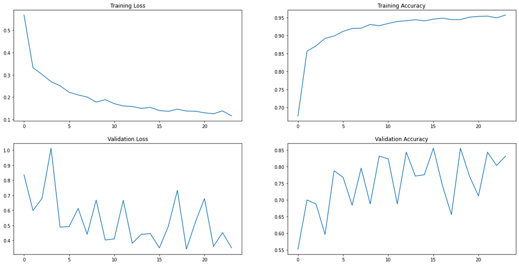

```python
fig, ((loss_ax, acc_ax), (val_loss_ax, val_acc_ax)) = plt.subplots(2, 2, figsize=(20, 10))

loss_ax.plot(history.history['loss'])
loss_ax.set_title('Training Loss')

acc_ax.plot(history.history['accuracy'])
acc_ax.set_title('Training Accuracy')

val_loss_ax.plot(history.history['val_loss'])
val_loss_ax.set_title('Validation Loss')

val_acc_ax.plot(history.history['val_accuracy'])
val_acc_ax.set_title('Validation Accuracy');
```

# Performance Testing

Model performance can be measured by a multitude of different metrics. Thankfully, `sklearn` is nice and gives us a function (`sklearn.metrics.classification_report`) that evaluates all of the main numerical performance metrics for us. We'll also be computing a confusion matrix for the data, which will be discussed later.

```python
test_waves, test_labels = [], []
for i, row in tqdm(test_df.iterrows(), total=len(test_df)):
    test_waves.append(preprocess_wave(load_waveform(TEST_FOLDER / f"{row['wave']}.mat")))
    test_labels.append(row['label'])

test_data = reshape_for_NN(np.asarray(test_waves))
test_labels = [0 if i == 'N' else 1 for i in test_labels]

test_preds = np.argmax(model.predict(test_data), axis=1)
```

```python
from sklearn.metrics import classification_report

print(classification_report(test_labels, test_preds))
```

```
              precision    recall  f1-score   support

           0       0.98      0.96      0.97       134
           1       0.89      0.95      0.92        43

    accuracy                           0.96       177
   macro avg       0.94      0.96      0.95       177
weighted avg       0.96      0.96      0.96       177
```

Now, while all of these look pretty good, the important thing to notice is the distribution of the test labels. As we can see in the support column, we have nearly 3 times as many normal ECG waves as we do AFib waves. Thus, we need to use a confusion matrix to see really see how well the model performs. Confusion matrices measure the performance of the model over all possible classes. Each cell gives the proportion of images with a given label that are classified to be of another given label. Ideally, we want the matrix to be "lit up" along the diagonal, which would indicate that the model has a very low chance of misidentifying a given image. Furthermore, we can use that idea to generate a perfmorance measure from the confusion matrix, which for the sake of simplicity we'll call a CM score. The metric will be the trace of the confusion matrix (i.e. the sum of the confusion matrix's diagonal entries). Since we want the matrix to eb as close as possible to an identity matrix (i.e. 1's on the main diagonal and 0's everywhere else), the higher the CM score is the better our model will perform.

Let's get to plotting!

```python
import seaborn as sns
from sklearn.metrics import confusion_matrix

def plot_confmat(true_labels, pred_labels):
    """
    Plots a confusion matrix from given data
    """
    fig2, ax = plt.subplots(1, 1, num=2, figsize=(15, 10))

    cm = confusion_matrix(true_labels, pred_labels)
    cm_norm = cm.astype('float') / cm.sum(axis=1)[:, np.newaxis]  # normalize the confusion matrix
    for pair in np.argwhere(np.isnan(cm_norm)):
        cm_norm[pair[0]][pair[1]] = 0

    annot = np.zeros_like(cm, dtype=object)
    for i in range(annot.shape[0]):  # Creates an annotation array for the heatmap
        for j in range(annot.shape[1]):
            annot[i][j] = f'{cm[i][j]}\n{round(cm_norm[i][j] * 100, ndigits=3)}%'

    ax = sns.heatmap(cm_norm, annot=annot, fmt='', cbar=True, cmap=plt.cm.magma, vmin=0, ax=ax) # plot the confusion matrix

    ax.set(xlabel='Predicted Label', ylabel='Actual Label')

    cm_score = np.trace(cm_norm)

    print(f'CM Score: {cm_score}')

    fig2.tight_layout()
```

```
CM Score: 1.9161749392572025
```

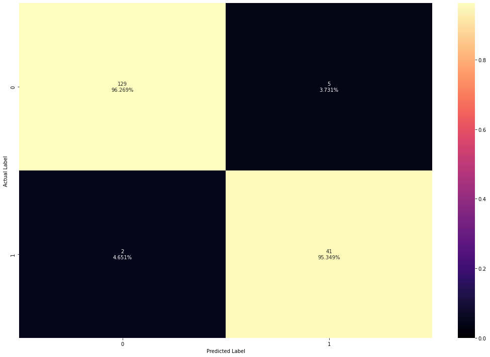

```python
plot_confmat(test_labels, test_preds)
```

Hey, that's pretty good! Actually, it's extraordinarily good, which can be evidenced also by the CM score being very close to 2. As such, we're done here. We've successfully trained a performant CNN for diagnosing atrial fibrillation from an ECG wave.

# Recap

To recap, we used ECG waves in order to tell whether a given patient had AFib. The ECG waves were intially very noisy, so we used a Butterworth filter in order to clean up the waves, before normalizing the waves. We then partitioned our data into training, validation, and testing data, and used the SMOTE oversampling technique to balance our training set. We then trained a 1D CNN on this training data, montioring its progress through the validation set and stopping it before the model started overfitting. As we demonstrated in our performance metrics, the resulting model was surprisingly good at predicting whether a given patient had AFib or not from their ECG wave.

# Possible Future Directions

Now that we have a working model, it would be really cool if we had some way of testing it in a real-world setting. One of the more fun possibilities involve using recent developments in wearable technology in order to monitor the heartbeat of the wearer. Apple Watches have the capability of [recording an ECG wave](https://support.apple.com/en-us/HT208955), and other Android Wear devices have [similar capabilities](https://www.mobihealthnews.com/news/north-america/fossils-latest-smartwatch-comes-preloaded-cardiogram). Given that we have a very light model (~214,000 parameters), the cost of prediction should be cheap enough that it can be done on a phone or wearable device, so it would be feasible to try and build this model into an app for such devices.

Furthermore, extending this model to account for other types of fibrillation would be an interesting direction of research. [Ventricular fibrillation](https://www.hopkinsmedicine.org/health/conditions-and-diseases/ventricular-fibrillation) is a much more dangerous type of arrythmia than AFib, and thus would be extraordinarily valuable to be able to predict.

In any case, I hope that this tutorial was informative. Thanks for reading!